# de novo Occular transcriptomes: results

After our trancriptome, we reconstructed much of the refernece transcriptome, as well as novel transcripts, which we define as novel isoforms of known genes, and novel loci, which we define as transcripts whose complete sequence has not been previously annotated

|  | description | value |
| --- | --- | --- |
| 1 | number of tissues | 53 |
| 2 | number of samples | 1057 |
| 3 | number of transcripts constructed | 254995 |
| 4 | number of novel transcripts | 67852 |
| 5 | number of novel loci | 3188 |

Novel transcripts are broken down into 3 catagories - noncoding, protein coding but no change in the coding region of the transcript, or a change in the coding region of the transcripts. Novel Loci can be broken down into coding or non coding.

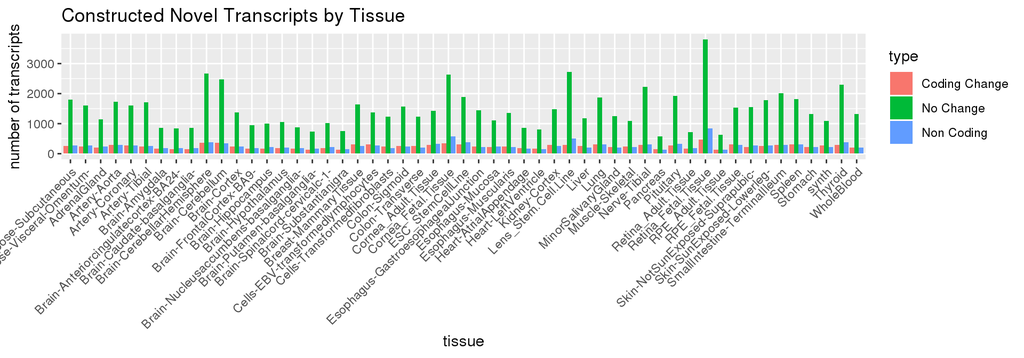

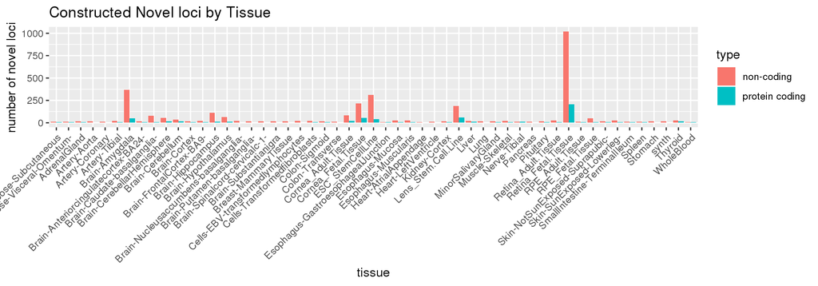

Novel transcripts are novel due to one or more novel/unannotated exon. We can group novel exons into 2 distinct categories: modifcations of existing exons - alternative exons, or completely distinct regions of transcibed sequence - fully novel exons. We then wanted to identify what biological process might be driving the formation of these novel exons 3 major sources of transcriptional variation are alternative splicing, Alternative first exon usage, and alternative terminal exon usage(alternative polyadenylation).

|  | desc | value |
| --- | --- | --- |
| 1 | Number of Alternative Exons | 53829 |
| 2 | Number of Fully Novel Exons | 9549 |

|  | desc | count |
| --- | --- | --- |
| 1 | Alternative Splicing | 38424 |
| 2 | Novel Transcriptional Start Site | 12438 |
| 3 | Novel Transcriptional Termination Site | 12516 |

Next, using the contructed transcriptomes for each tisssue, we analyzed splicing patterns for both reference and novel exons

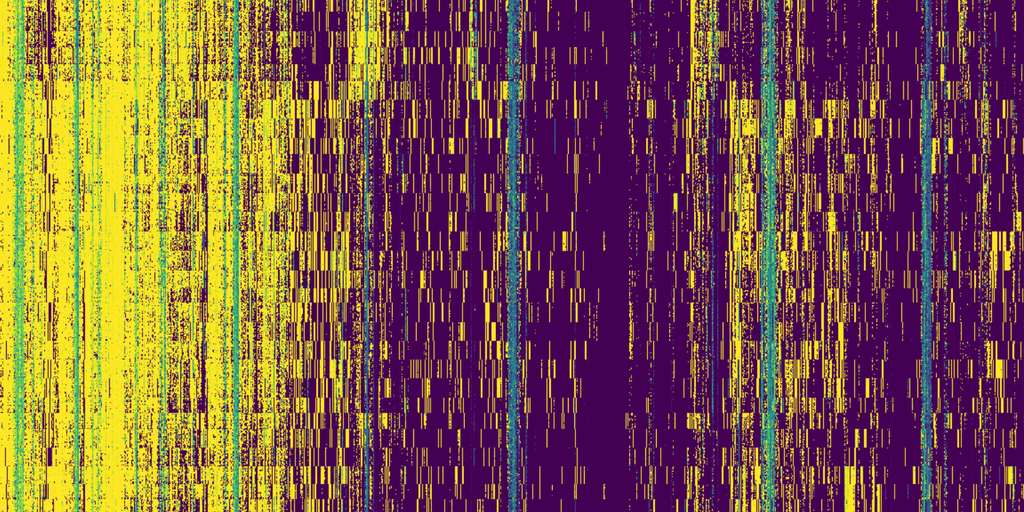

While the expression of some exons is ubiquitous across tissues, we can see clear regions in the heatmap that denote tissue specifc splicing